# Supplementary Information: Models

Laura Geronimo

## Full Sample Diagnostics

##M0 Stepwise regression on full model - all variables

Here I add all variables to the regression model and then apply stepwise AIC to see what variables are selected

### Examining model chosen via stepwise

#### Examining variables for multicolinearity: Corr matrix and Vif test on non FE vars

```
##                 TotPop_W_10k                        fHisp
##                    24.927558                     1.222333
##                 MHIadj_W_10k                MHVadj_W_100k
##                     2.736019                     4.537955
##                  TotHU_W_10k                    fS2ndHome
##                    28.107324                     1.178322
##              TaxBaseEst_1B_W                   ZCTA_shore
##                     6.933857                     1.201278
##         count_fema_sfha_W_1k        NFIP_ICCadj_YOLZ_W_1M
##                     1.420702                     1.368264
## IHP_fldDamAmountAdjDNZ_W_10M
##                     1.316421
```

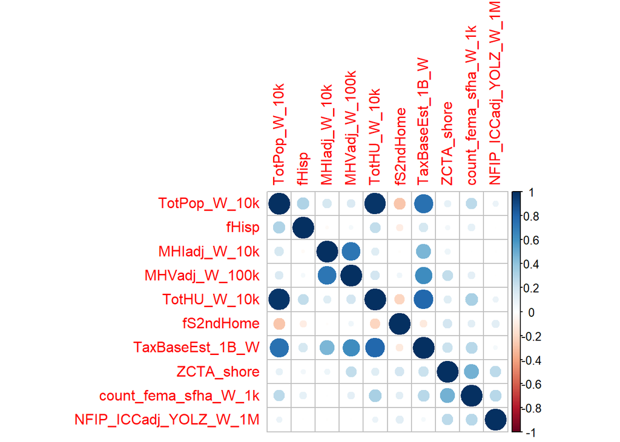

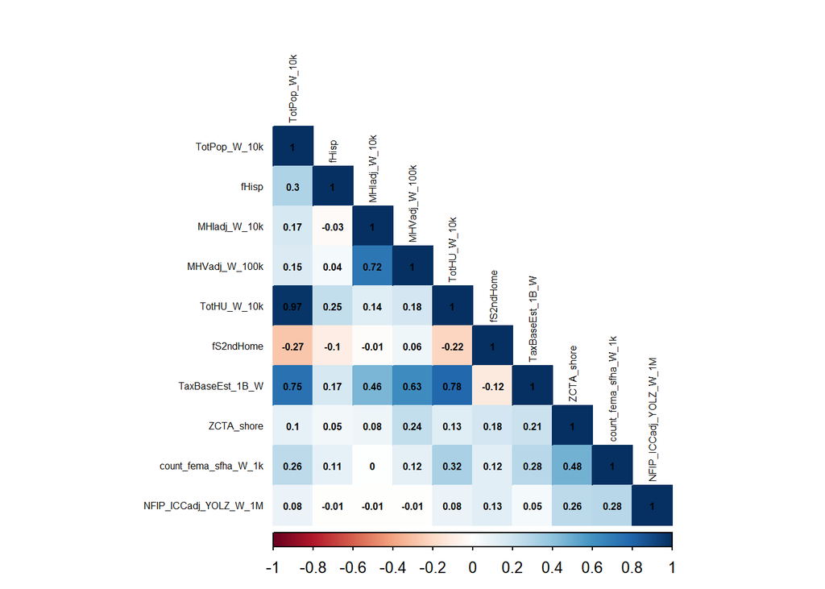

### SVSS test

Running SVSS test to see which variables are included

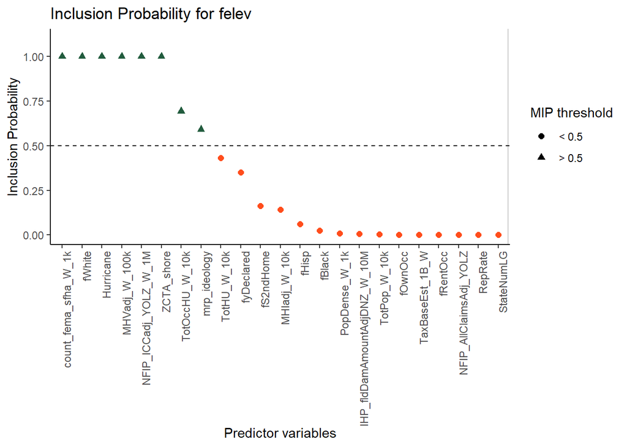

#### Logistic model comparing original Dissertation model with SVSS predictors

##Correlation Matrices on select vars Note that in preparation for modeling, we examine all of the variables recommended in the SVSS test, plus variables that were significant in the Chi-Square and Anova tests, and are relevant to the literature based on domain knowledge.

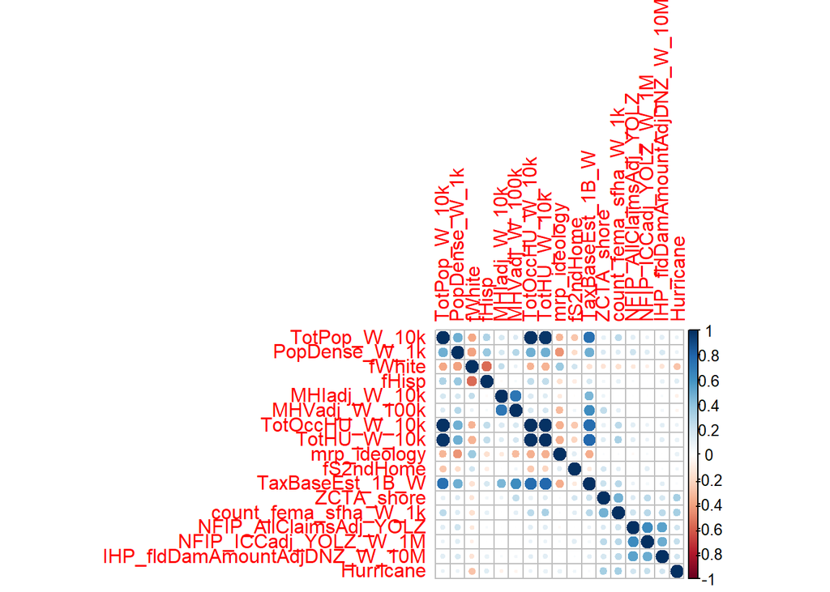

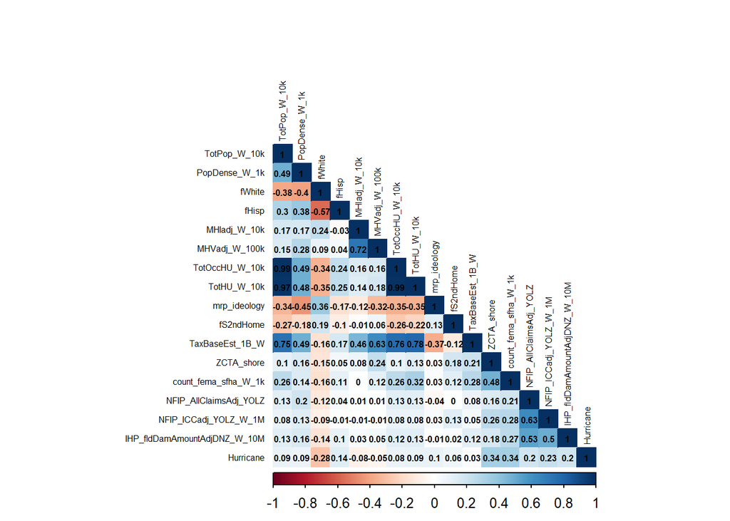

Given the high correlation between MHV and MHI, we drop MHI.

Some notes: -MPR ideology is negatively correlated with MHV: as MHV increase, republican ideology decreases (suggests lower-income is correlated with republicanism) -Tax base and MHV are positively correlated -FWhite and MPR ideology are positively correlated

##Stepwise Regression

## Model 1: All hypotheses

##### Correlation Matrices for M1

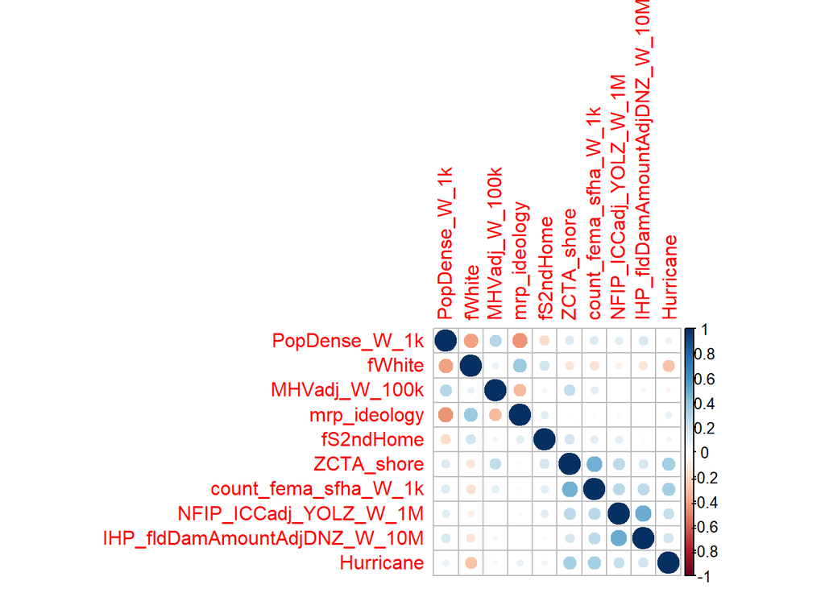

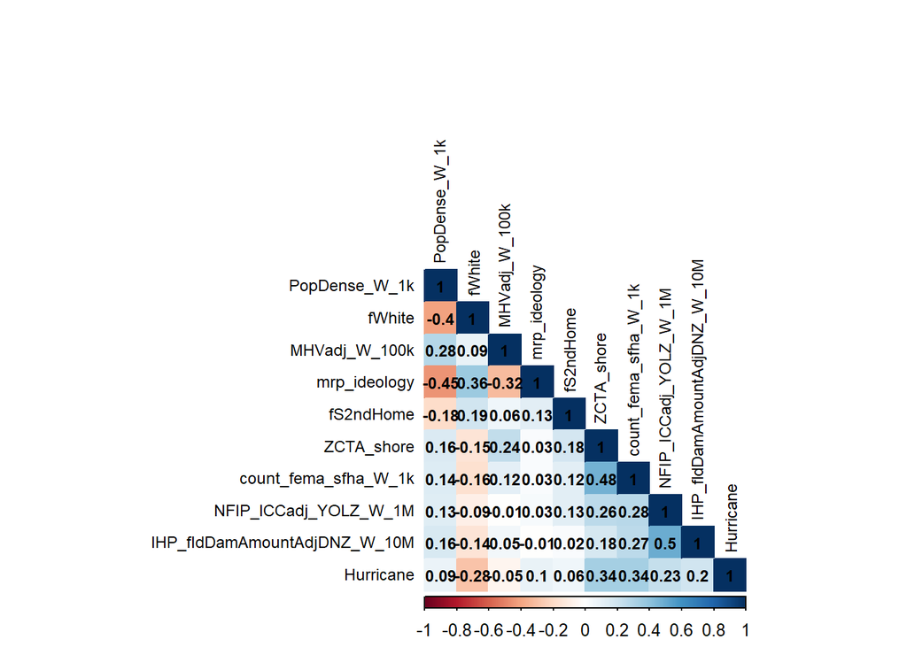

##### M1 - Full model WITHOUT fixed effects & select vars

Note that we order these so that the hypotheses being tested are at the top, followed by control variables

##### M1 - Full model with fixed effects & select vars

**Logit Model 1B: Full sample (testing Race and MHV**

|  | *Dependent variable:* |
| --- | --- |
|  | odds Ratio of felev |
| MHV (100k W) | 0.85 |
|  | (0.19) |
| Fraction White | 0.67 |
|  | (0.44) |
| Conservative Ideology | 1.21 |
|  | (0.31) |
| Fraction 2nd Homes | 10.09*** |
|  | (0.31) |
| Shoreline ZCTA | 4.11*** |
|  | (0.11) |
| Hurricane | 1.15 |
|  | (0.14) |
| Count of HUs in FEMA SFHA 1k (W) | 1.18*** |
|  | (0.03) |
| NFIP ICC Claims 1M (W) by ZCTA-YOL | 1.37*** |
|  | (0.12) |
| Population Density 1k (W) | 1.00 |
|  | (0.04) |
| MHV:Fraction White interaction | 1.52* |
|  | (0.22) |
| Constant | 0.00 |
|  | (3,487.30) |
| State FE | YES |
| Year FE | YES |
| Pseudo R2 | 0.48 |
| Observations | 5,658 |
| Log Likelihood | -1,585.90 |
| Akaike Inf. Crit. | 3,355.79 |
| *Note:* | p<0.1; p<0.05; p<0.01 |

**Logit Model Comparison: Single Variable Mode**

|  | *Dependent variable:* |  |  |  |  |  |  |  |  |  |  |
| --- | --- | --- | --- | --- | --- | --- | --- | --- | --- | --- | --- |
|  | odds Ratio of felev |  |  |  |  |  |  |  |  |  |  |
|  | (1) | (2) | (3) | (4) | (5) | (6) | (7) | (8) | (9) | (10) | (11) |
| MHV (100k W) |  | 1.43*** |  |  |  |  |  |  |  |  | 0.94 |
|  |  | (0.04) |  |  |  |  |  |  |  |  | (0.17) |
| Fraction White |  |  | 3.53*** |  |  |  |  |  |  |  | 1.30 |
|  |  |  | (0.21) |  |  |  |  |  |  |  | (0.36) |
| Conservative Ideology |  |  |  | 2.12*** |  |  |  |  |  |  |  |
|  |  |  |  | (0.20) |  |  |  |  |  |  |  |
| Fraction 2nd Homes |  |  |  |  | 27.03*** |  |  |  |  |  |  |
|  |  |  |  |  | (0.26) |  |  |  |  |  |  |
| Shoreline ZCTA |  |  |  |  |  | 6.45*** |  |  |  |  |  |
|  |  |  |  |  |  | (0.10) |  |  |  |  |  |
| Hurricane |  |  |  |  |  |  | 1.53*** |  |  |  |  |
|  |  |  |  |  |  |  | (0.12) |  |  |  |  |
| Count of HUs in FEMA SFHA 1k (W) |  |  |  |  |  |  |  | 1.42*** |  |  |  |
|  |  |  |  |  |  |  |  | (0.03) |  |  |  |
| NFIP ICC Claims 1M (W) by ZCTA-YOL |  |  |  |  |  |  |  |  | 2.32*** |  |  |
|  |  |  |  |  |  |  |  |  | (0.12) |  |  |
| Population Density 1k (W) |  |  |  |  |  |  |  |  |  | 1.00 |  |
|  |  |  |  |  |  |  |  |  |  | (0.03) |  |
| MHV:Fraction White interaction |  |  |  |  |  |  |  |  |  |  | 1.61** |
|  |  |  |  |  |  |  |  |  |  |  | (0.20) |
| Constant | 0.00 | 0.00 | 0.00 | 0.00 | 0.00 | 0.00 | 0.00 | 0.00 | 0.00 | 0.00 | 0.00 |
|  | (3,454.33) | (3,425.01) | (3,426.37) | (3,458.57) | (3,403.40) | (3,526.15) | (3,467.33) | (3,481.96) | (3,460.65) | (3,454.32) | (3,406.73) |
| State FE | YES | YES | YES | YES | YES | YES | YES | YES |  |  |  |
| Year FE | YES | YES | YES | YES | YES | YES | YES | YES |  |  |  |
| Pseudo R2 | 0.38 | 0.4 | 0.39 | 0.39 | 0.41 | 0.45 | 0.39 | 0.42 | 0.39 | 0.38 | 0.4 |
| Observations | 5,658 | 5,658 | 5,658 | 5,658 | 5,658 | 5,658 | 5,658 | 5,658 | 5,658 | 5,658 | 5,658 |
| Log Likelihood | -1,876.06 | -1,839.69 | -1,857.04 | -1,868.80 | -1,784.16 | -1,672.39 | -1,870.24 | -1,779.95 | -1,846.44 | -1,876.07 | -1,826.82 |
| Akaike Inf. Crit. | 3,916.13 | 3,845.38 | 3,880.09 | 3,903.60 | 3,734.32 | 3,510.78 | 3,906.48 | 3,725.89 | 3,858.87 | 3,918.13 | 3,823.64 |
| *Note:* | p<0.1; p<0.05; p<0.01 |  |  |  |  |  |  |  |  |  |  |

##### Model Series A.1 (Starting with best model from above and dropping vars)

**Logit Model Comparison: Full Sample, Dropping variables**

|  | *Dependent variable:* |  |  |  |  |  |  |  |  |  |  |
| --- | --- | --- | --- | --- | --- | --- | --- | --- | --- | --- | --- |
|  | Odds Ratio of felev |  |  |  |  |  |  |  |  |  |  |
|  | (1) | (2) | (3) | (4) | (5) | (6) | (7) | (8) | (9) | (10) | (11) |
| MHV (100k W) | 0.85 | 0.85 | 0.85 | 0.85 | 0.82 | 0.91 | 0.85 | 0.87 | 0.86 | 0.85 | 1.20*** |
|  | (0.19) | (0.19) | (0.19) | (0.19) | (0.19) | (0.19) | (0.19) | (0.19) | (0.19) | (0.18) | (0.05) |
| Fraction White | 0.67 | 0.67 | 0.67 | 0.76 | 0.82 | 0.46* | 0.67 | 0.80 | 0.70 | 0.67 | 1.21 |
|  | (0.44) | (0.44) | (0.44) | (0.39) | (0.44) | (0.42) | (0.44) | (0.44) | (0.44) | (0.44) | (0.32) |
| Conservative Ideology | 1.21 | 1.21 | 1.21 |  | 1.41 | 2.21*** | 1.21 | 1.08 | 1.19 | 1.20 | 1.12 |
|  | (0.31) | (0.31) | (0.31) |  | (0.30) | (0.30) | (0.31) | (0.31) | (0.31) | (0.30) | (0.30) |
| Fraction 2nd Homes | 10.09*** | 10.09*** | 10.09*** | 10.19*** |  | 15.45*** | 10.13*** | 10.72*** | 10.68*** | 10.06*** | 10.26*** |
|  | (0.31) | (0.31) | (0.31) | (0.31) |  | (0.30) | (0.31) | (0.31) | (0.31) | (0.30) | (0.31) |
| Shoreline ZCTA | 4.11*** | 4.11*** | 4.11*** | 4.16*** | 4.58*** |  | 4.14*** | 4.86*** | 4.22*** | 4.12*** | 4.13*** |
|  | (0.11) | (0.11) | (0.11) | (0.11) | (0.11) |  | (0.11) | (0.11) | (0.11) | (0.11) | (0.11) |
| Hurricane | 1.15 | 1.15 | 1.15 | 1.15 | 1.17 | 1.27* |  | 1.18 | 1.16 | 1.15 | 1.15 |
|  | (0.14) | (0.14) | (0.14) | (0.14) | (0.14) | (0.14) |  | (0.14) | (0.14) | (0.14) | (0.14) |
| Count of HUs in FEMA SFHA 1k (W) | 1.18*** | 1.18*** | 1.18*** | 1.18*** | 1.19*** | 1.33*** | 1.18*** |  | 1.20*** | 1.18*** | 1.18*** |
|  | (0.03) | (0.03) | (0.03) | (0.03) | (0.03) | (0.03) | (0.03) |  | (0.03) | (0.03) | (0.03) |
| NFIP ICC Claims 1M (W) by ZCTA-YOL | 1.37*** | 1.37*** | 1.37*** | 1.37*** | 1.48*** | 1.58*** | 1.37*** | 1.53*** |  | 1.37*** | 1.36** |
|  | (0.12) | (0.12) | (0.12) | (0.12) | (0.12) | (0.12) | (0.12) | (0.12) |  | (0.12) | (0.12) |
| Population Density 1k (W) | 1.00 | 1.00 | 1.00 | 1.00 | 0.96 | 1.05 | 1.00 | 1.01 | 1.02 |  | 0.98 |
|  | (0.04) | (0.04) | (0.04) | (0.04) | (0.04) | (0.04) | (0.04) | (0.04) | (0.04) |  | (0.04) |
| MHV:Fraction White interaction | 1.52* |  | 1.52* | 1.49* | 1.64** | 1.57** | 1.52* | 1.48* | 1.50* | 1.51* |  |
|  | (0.22) |  | (0.22) | (0.22) | (0.22) | (0.22) | (0.23) | (0.22) | (0.22) | (0.22) |  |
| fWhite:MHVadj_W_100k |  | 1.52* |  |  |  |  |  |  |  |  |  |
|  |  | (0.22) |  |  |  |  |  |  |  |  |  |
| Constant | 0.00 | 0.00 | 0.00 | 0.00 | 0.00 | 0.00 | 0.00 | 0.00 | 0.00 | 0.00 | 0.00 |
|  | (3,487.30) | (3,487.30) | (3,487.30) | (3,484.79) | (3,512.90) | (3,441.23) | (3,483.64) | (3,477.51) | (3,486.52) | (3,487.32) | (3,489.06) |
| State FE | YES | YES | YES | YES | YES | YES | YES | YES | YES | YES | YES |
| Year FE | YES | YES | YES | YES | YES | YES | YES | YES | YES | YES | YES |
| Pseudo R2 | 0.48 | 0.48 | 0.48 | 0.48 | 0.47 | 0.45 | 0.48 | 0.48 | 0.48 | 0.48 | 0.48 |
| Observations | 5,658 | 5,658 | 5,658 | 5,658 | 5,658 | 5,658 | 5,658 | 5,658 | 5,658 | 5,658 | 5,658 |
| Log Likelihood | -1,585.90 | -1,585.90 | -1,585.90 | -1,586.01 | -1,616.86 | -1,677.15 | -1,586.32 | -1,603.72 | -1,589.61 | -1,585.90 | -1,587.21 |
| Akaike Inf. Crit. | 3,355.79 | 3,355.79 | 3,355.79 | 3,354.01 | 3,415.73 | 3,536.31 | 3,354.64 | 3,389.43 | 3,361.22 | 3,353.80 | 3,356.42 |
| *Note:* | p<0.1; p<0.05; p<0.01 |  |  |  |  |  |  |  |  |  |  |

##### Post Tests M1

##### Examining outliers and leverage points

###### Diagnostics:

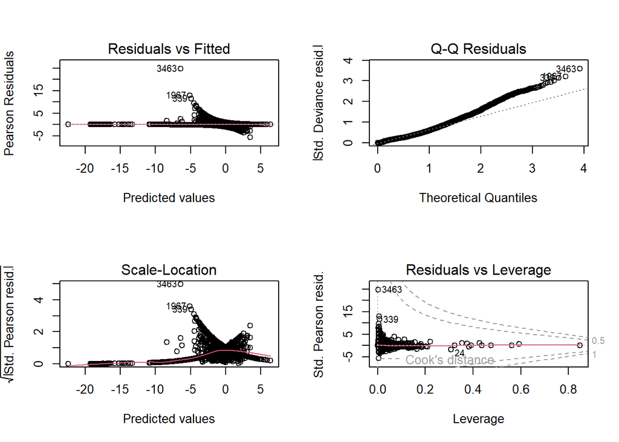

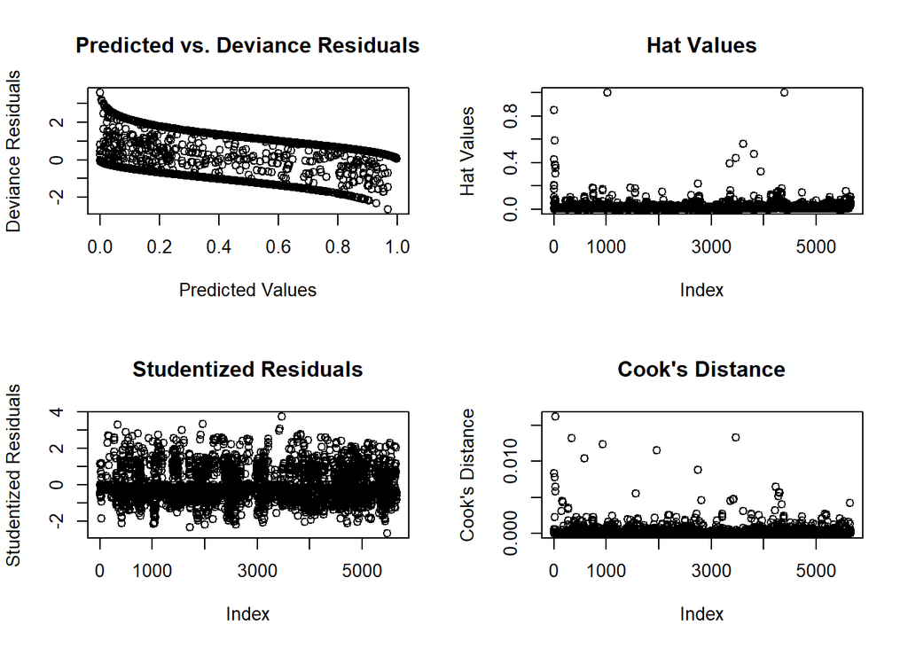

```
## No Studentized residuals with Bonferroni p < 0.05
## Largest |rstudent|:
##      rstudent unadjusted p-value Bonferroni p
## 3463 3.748546         0.00017786           NA
```

######Identifying influential observations

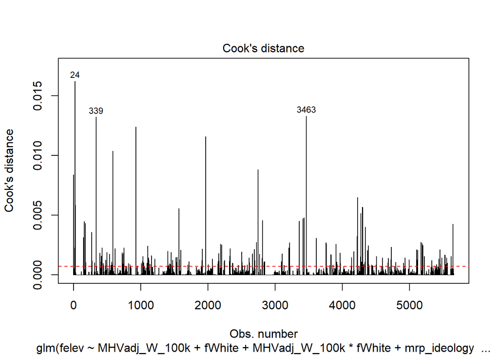

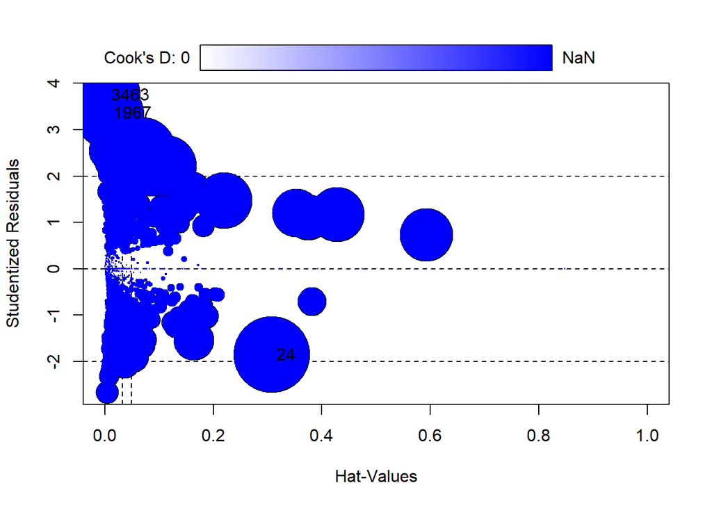

```
##        StudRes         Hat      CookD
## 24   -1.854237 0.307278164 0.01620882
## 1025       NaN 1.000000000        NaN
## 1967  3.362059 0.006294327 0.01156206
## 3463  3.748546 0.001996255 0.01329423
## 4397       NaN 1.000000000        NaN
```

### M1_Unlev: Dropping leverage points and rerunning model

**Logit Model Comparison: Dropping Influential Observations**

|  | *Dependent variable:* |
| --- | --- |
|  | Odds Ratio of felev |
| MHV (100k W) | 0.841 |
|  | (0.193) |
| Fraction White | 0.633 |
|  | (0.446) |
| Conservative Ideology | 1.239 |
|  | (0.310) |
| Fraction 2nd Homes | 10.367*** |
|  | (0.310) |
| Shoreline ZCTA | 4.120*** |
|  | (0.110) |
| Hurricane | 1.143 |
|  | (0.141) |
| Count of HUs in FEMA SFHA 1k (W) | 1.183*** |
|  | (0.030) |
| NFIP ICC Claims 1M (W) by ZCTA-YOL | 1.367*** |
|  | (0.121) |
| Population Density 1k (W) | 1.001 |
|  | (0.036) |
| MHV:Fraction White interaction | 1.549* |
|  | (0.225) |
| 2 | 0.000 |
|  | (5,747.714) |
| State FE | Yes |
| Year FE | Yes |
| Pseudo R2 | 0.49 |
| Observations | 5,651 |
| Log Likelihood | -1,564.594 |
| Akaike Inf. Crit. | 3,309.189 |
| *Note:* | p<0.1; p<0.05; p<0.01 |

##### Post Tests M1_unLev

##### Examining outliers and leverage points

###### Diagnostics

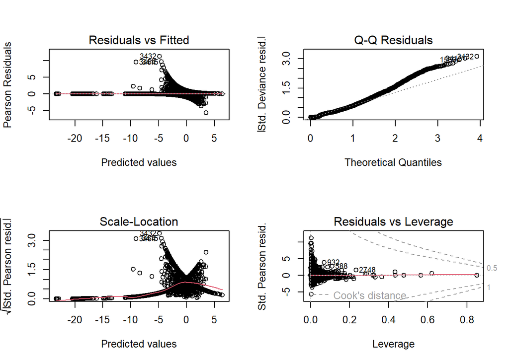

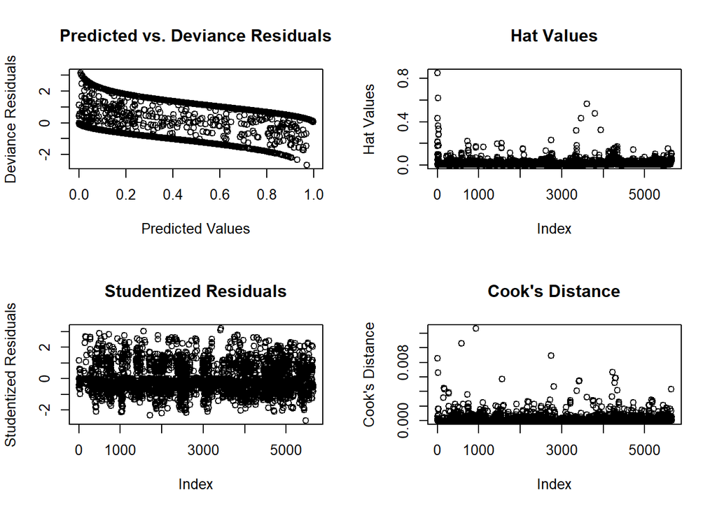

```
## No Studentized residuals with Bonferroni p < 0.05
## Largest |rstudent|:
##      rstudent unadjusted p-value Bonferroni p
## 3432 3.193779          0.0014042           NA
```

######Identifying influential observations

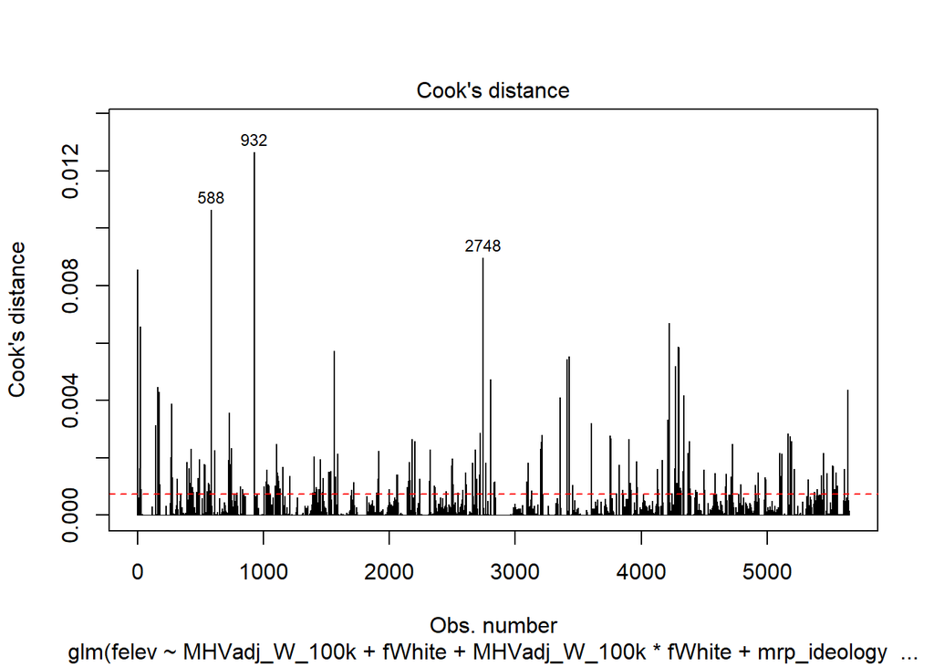

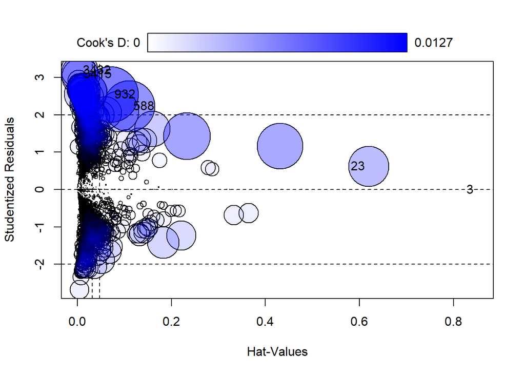

```
##            StudRes         Hat            CookD
## 3    -0.0004519244 0.850932829 0.00000001127345
## 23    0.6192434672 0.619981195 0.00656816260887
## 588   2.2287062339 0.110925961 0.01064578630437
## 932   2.5426490107 0.070684704 0.01266274847144
## 3415  3.0944892727 0.005188271 0.00542662819556
## 3432  3.1937791663 0.003880617 0.00552186302606
```

###### Drawing predicted probabilities

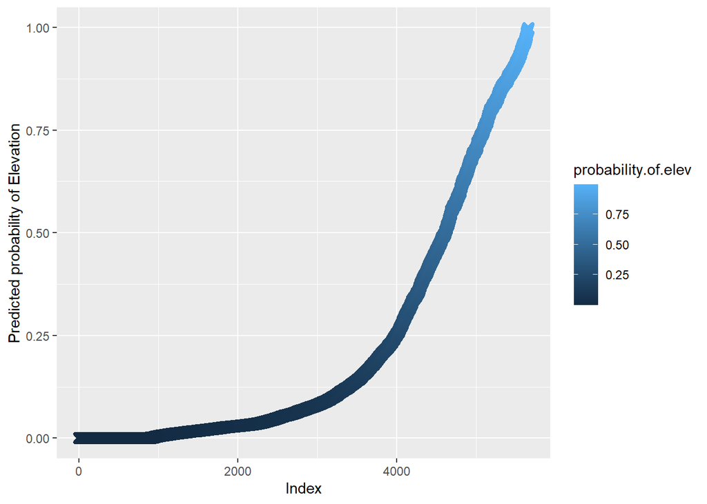

##### Cross validation

###### Confusion Matrix

```
## Confusion Matrix and Statistics
##
##           Reference
## Prediction Acqui Elev
##      Acqui   802   64
##      Elev     43  144
##
##                Accuracy : 0.8984
##                  95% CI : (0.8785, 0.916)
##     No Information Rate : 0.8025
##     P-Value [Acc > NIR] : < 0.0000000000000002
##
##                   Kappa : 0.6668
##
##  Mcnemar's Test P-Value : 0.05318
##
##             Sensitivity : 0.9491
##             Specificity : 0.6923
##          Pos Pred Value : 0.9261
##          Neg Pred Value : 0.7701
##              Prevalence : 0.8025
##          Detection Rate : 0.7616
##    Detection Prevalence : 0.8224
##       Balanced Accuracy : 0.8207
##
##        'Positive' Class : Acqui
##
```